# Part I - (Loan Data from Prosper)

> Examine the relationship between the Loan Original Amount and Loan Status.

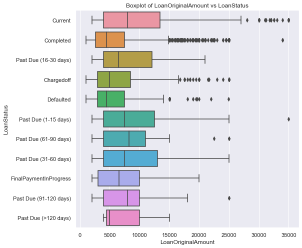

```python
boxplot('LoanOriginalAmount', 'LoanStatus')
```

- Those that defaulted appear to have received the lowest amount of loan

> Examine the relationship between the Borrower APR and Available Bank card Credit.

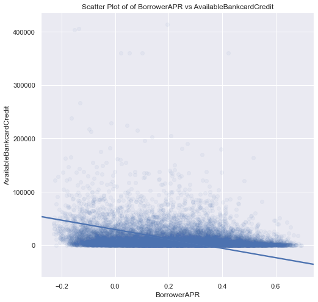

```python
scatter('BorrowerAPR', 'AvailableBankcardCredit')
```

- There exist a slight negative correlation between this two variables

> Examine the relationship between the Borrower APR and Amount Delinquent

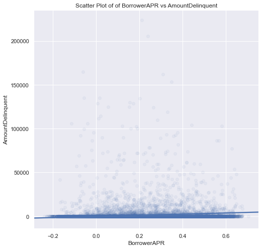

```python
scatter( 'BorrowerAPR', 'AmountDelinquent')
```

- There exist a no significant correlation between this two variables

> Examine the relationship between the Loan Original Borrower APR and Investors

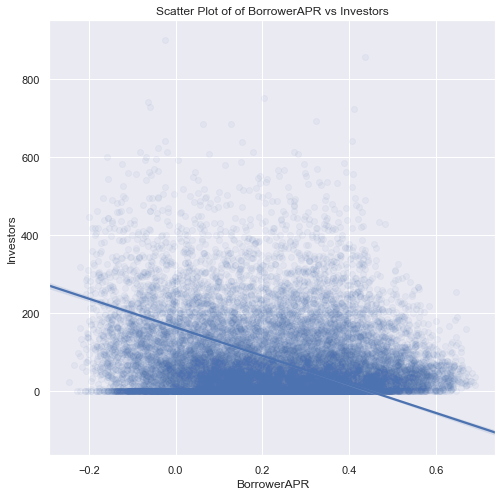

```python
scatter('BorrowerAPR','Investors')
```

- There exist a negative correlation between this two variables

> Examine the relationship between the Loan Original Amount and Borrower APR.

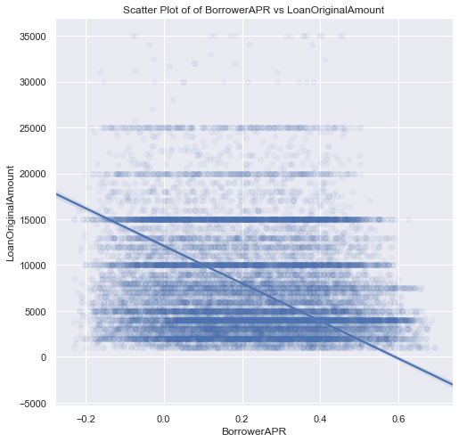

```python
scatter('BorrowerAPR','LoanOriginalAmount')
```

- There exist a negative correlation between this two variables

> Examine the relationship between the Borrower APR and Stated Monthly Income.

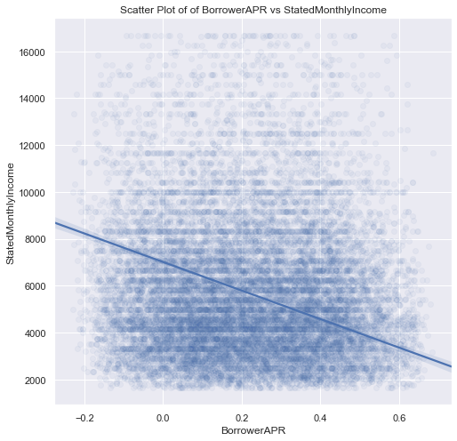

```python
scatter('BorrowerAPR','StatedMonthlyIncome')
```

- There exist a negative correlation between this two variables

> Examine the relationship between the BorrowerAPR and Term.

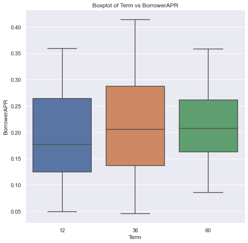

```python
boxplot('Term', 'BorrowerAPR')
```

- There is no major change in the Borrower APR according to term

### Talk about some of the relationships you observed in this part of the investigation. How did the feature(s) of interest vary with other features in the dataset?

> There exsit a major relationship between Income, Employment Status between the original loan amount issued and loan status.

### Did you observe any interesting relationships between the other features (not the main feature(s) of interest)?

> The fact that the bulk of defaulter received the lowest original amount of loan.

## Multivariate Exploration

> We examine the relationship present between The Loan orginal amount and Monthly Loan Payment plan for each unique term

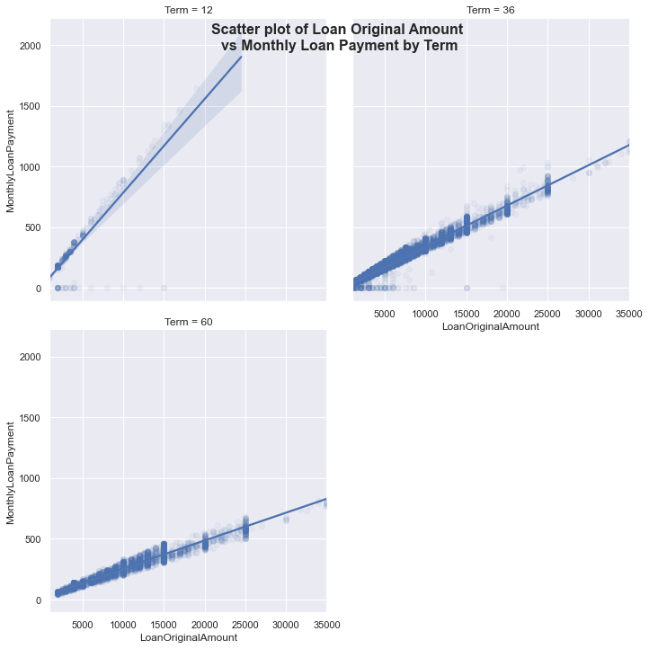

```python
l = sns.lmplot(
    x='LoanOriginalAmount',
    y='MonthlyLoanPayment',
    data=data,
    palette='bright',
    col='Term',
    x_jitter=0.3, col_wrap=2, scatter_kws={'alpha':1/20})

# Access the figure
fig = l.fig

# Add a title to the Figure
fig.suptitle("""
    Scatter plot of Loan Original Amount
    vs Monthly Loan Payment by Term
    """, fontsize=16, weight = "bold");
```

From can see that the relationship between Loan orginal amount and Monthly Loan Payment plan is relative close fro the various terms

> Examination of the relationship between the original loan amount and Borrower APR for each Loan Status

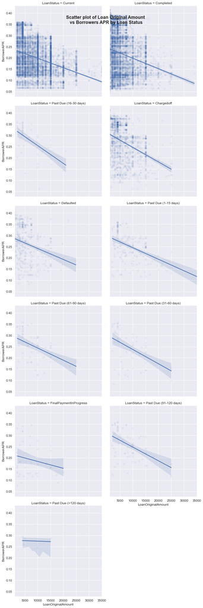

```python
k = sns.lmplot(
    x='LoanOriginalAmount',
    y='BorrowerAPR',
    data=data,
    palette='bright',
    col='LoanStatus',
    x_jitter=0.3, col_wrap=2, scatter_kws={'alpha':1/20});

# Access the figure
fig = k.fig

# Add a title to the Figure
fig.suptitle("""
    Scatter plot of Loan Original Amount
    vs Borrowers APR by Loan Status
    """, fontsize=16, weight = "bold");
```

We can see a negative correlation exist between the Loan Original Amount and Borrower APR for all the loan status except those pass their due date by 120 days

> Here we create a fuction for estimating the relationship between two categorical features and a numerical feature.

Function below accepts the three variables, the first two are categorical whhile the third is anumeriacl feature.

```python
def cat_mean(var_1, var_2, var_3):
    cat_means = data.groupby([var_1, var_2]).mean()[var_3]
    cat_means = cat_means.reset_index(name = 'num_var2_avg')
    cat_means = cat_means.pivot(index = var_2, columns = var_1,
                                values = 'num_var2_avg')

    sns.heatmap(cat_means, annot = True, fmt = '.3f',
               cbar_kws = {'label' : f'mean({var_3})'});
```

> We start by examining the mean values of the borrower APR after grouping the data by term and Loan Status.

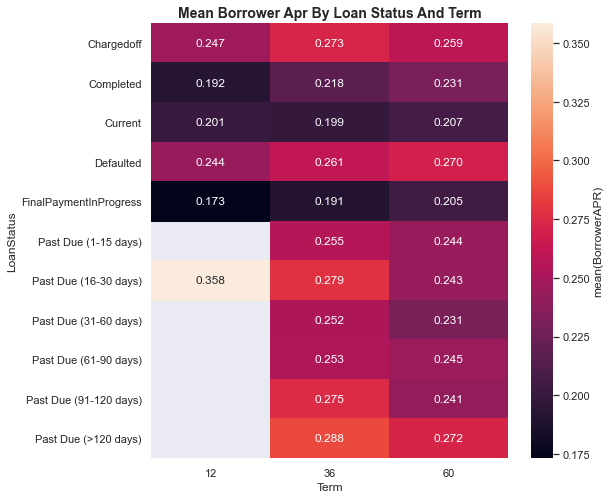

```python
cat_mean('Term', 'LoanStatus', 'BorrowerAPR')
plt.title('Mean Borrower APR by Loan Status and Term'.title(),
               fontsize = 14, weight = "bold");
```

> We start by examining the mean values of the borrower APR after grouping the data by Income range and Loan Status.

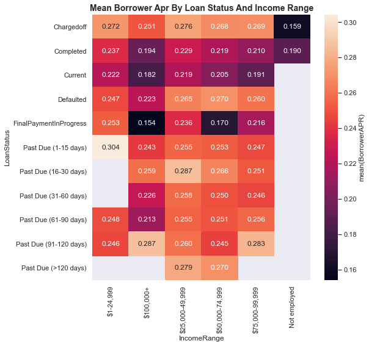

```python
cat_mean('IncomeRange', 'LoanStatus', 'BorrowerAPR')
plt.title('Mean Borrower APR by Loan Status and Income Range'.title(),
               fontsize = 14, weight = "bold");
```

> Observation from the above plot is quite profound:
> 1. For the 'Not Employed' column that those with a higher Borrower APR completed their Loan payment as compared with those with lower Borrower APR that were charged off.
> 2. For loan pass their due date by over 120 days, we observe that their Borrower APR are within the range of 0.27 to 0.28.
> 3. All those who were passed their due date for repayment had Borrower APR above 0.2

> We start by examining the mean values of the Monthly Loan Payment after grouping the data by Employment Status and Loan Status.

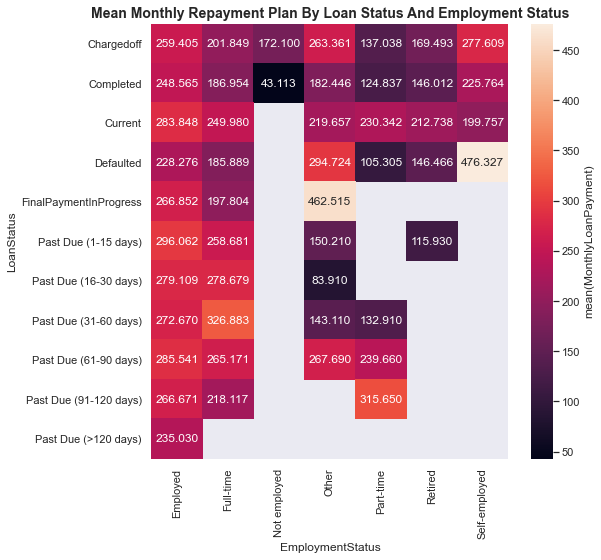

```python
cat_mean('EmploymentStatus', 'LoanStatus', 'MonthlyLoanPayment')
plt.title('Mean Monthly Repayment Plan by Loan Status and Employment Status'.title(),
               fontsize = 14, weight = "bold");
```

> Observation from the above plot is quite profound:
> 1. For the completed loan status appear to have the lowest cummulativemean of their monthly payment plan ranging from as low as 43 to a max of 248.
> 2. For the self employed class those that defaulted appear to have fallen into the group that made the highest payment of over 450.
> 3. The not employed either completed their payment or the loan were charged off. 0.2

> We start by examining the mean values of the Original Loan Amount after grouping the data by Income Range and Term.

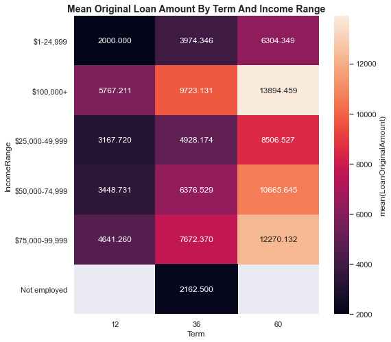

```python
cat_mean('Term', 'IncomeRange', 'LoanOriginalAmount')
plt.title('Mean Original Loan amount by Term and Income Range'.title(),
               fontsize = 14, weight = "bold");
```

We can see from all that the longer the term the higher the original amount of loan received irrespective of income range

### Talk about some of the relationships you observed in this part of the investigation. Were there features that strengthened each other in terms of looking at your feature(s) of interest?

> > For the above visualizations, We have a strong dependency of loan status on a number of factors such as the Higher the Borrower APR the higher the tendency for default on payment or for payment to be past its due date.

> > For the original amount of loan issued, it was observed to be dependent on a number of factors such as Income range of said individual, Employment Status and the number of months assign as repay plan. It was also observed of the lack of relationship better the amount of loan issued to the debit to income ratio of said individual.

> > For the Borrowers APR, we observed an inverse relationship mean for increase in Loan origninal amount and monthly require repayment amount; a decrease in the borrower APR we observed.

### Were there any interesting or surprising interactions between features?

> The presence of no significant relationship between the borrower APR and the term, of which i found quite surprising.

## Conclusions

> We started with prelimary wrangling after importing the data, which comprised of chaning the data types of some relevant features and fixing the issues with the null values.

> We then proceed with the use of Histogram, Horizontal bar chart and pie chart we were able to successful quiz the data on a univariate scale identifying outlier and other errors preforming the required corrective action each time.

> Proceeding further, we use the scatter plot and boxplot to quiz the data by comparing to features at a time. We end the quiz with the multivariate visualization were we viewed the presence or lack thereof of relationship between multiple features.

We observed the relationship between loan status and the Borrower APR.

Also the relationship between the original amount of loan issued, Income range of said individual, Employment Status and the number of months assign as repay plan.

Lastly the relationship between Borrowers APR, Loan origninal amount and monthly require repayment amount; a decrease in the borrower APR we observed.